# TEOS-10 Lab Assigment

Raymond Infante

2023-03-14

### Lab Assignment

1. Pick a question (Include hypothesis)
2. produce a plot and a statistical summary using lm()
3. Describe your results, the summary, and answer the question
4. Compile into a completed lab report using R Markdown

Potential questions: *how do temp, sal, and sigma-theta co-vary* Is there a relationship between sigma-theta and oxygen? *Is there a relationship of any of the parameter with depth? with time? within depth over time?* Are there seasonal differences in any of the parameters?

### Variables Names and Units

- yyyymmdd = Year Month Day
- decy = Decimal Year
- time = Time (hhmm)
- latN = Latitude (Deg N)
- lonW = Longitude (Deg W)
- Depth = Depth (m)
- Temp = Temperature ITS-90 (C)
- Pres = CTD Pressure (dbar)
- CTD_S = CTD Salinity (PSS-78)
- Sal1 = Salinity-1 (PSS-78)
- Sig-th = Sigma-Theta (kg/m^3) - density of seawater at a given temperature (Density - 1000)
- O2(1) = Oxygen-1 (umol/kg)
- OxFixT = Oxygen Fix Temp (C)
- Anom1 = Oxy Anomaly-1 (umol/kg)

### Quality flags

- -999 = No data
- 0 = Less than detection limit

# BATS Hydrostation S Information

BATS - Bermuda Atlantic Time-series Study was established with the mission of uncovering scientific mysteries of the deep ocean, doing this by analyzing hydrographical and biological data in the water column [BATS](https://bats.bios.edu/about/).

In this assignment, we are using Hydrostation S. This Station is part of BATS and was established in 1954 by Dr. Henry M. Stommel. This station has been continuously monitored biweekly, producing data on temperature, salinity and dissolved oxygen.

# TEOS-10 Information

In this assignment, we are using the TEOS-1O Gibbs Seawater (GSW) Oceanographic Toolbox. TEOS-10 is the International Thermodynamic Equation of Seawater-2010 and evaluates the thermodynamics properties of pure water, ice, seawater and moist air. TEOS-10 has introduced new variables such as Absolute Salinity, Preformed Salinity, and Conservative Temperature.

In this assignment we are using Conservative Temperature, which takes the place of potential temperature. According to TEOS-1O Gibbs Seawater (GSW) Oceanographic Toolbox, conservative temperature represents more accurately the heat content of seawater.

To obtain Conservative temperature, we first used the salinity, temperature, pressure, latitude, and longitudes variables to obtain absolute salinity. With the absolute salinity created, we used the gsw_CT_from_t function to obtain the conservative temperature, using this to answer our hypotheses.

Information about oxygen:

Dissolved Oxygen (DO) is a measure of the quantity of oxygen molecules in the water column. [USGS](https://www.usgs.gov/special-topics/water-science-school/science/dissolved-oxygen-and-water#overview). According to the USGS, the concentration of DO is affected by the temperature, cold water, holds more DO than warm water, and this can be seen in daily and seasonal cycles. In winter and spring the water temperature tends to be low (DO concentration high), as the inverse occurs in summer and fall, when water temperature are high (DO concentration will be lower). Retrieved from: [USGS](https://www.usgs.gov/special-topics/water-science-school/science/dissolved-oxygen-and-water#overview).

According to WOCE hydrographic program, the vertical profile of dissolved oxygen in the Atlantic Ocean is high at the surface, it reach a minimum at almost 1000m and have another maximum in depth of 2000m.

# Questions and Hypothesis

1. Is there a relationship between Conservative Temperature and Oxygen Concentration?
2. Is there any seasonal variability between this two?

# Ho

1. There is a correlation between Dissolved Oxygen and Conservative Temperature
2. The correlation between Dissolves Oxygen and Conservative Temperature varies seasonally and with depth.

## Data Wrangling for Conservative Temperature

```r
#Looking out for missing data


hydrostation_bottle %>%
  ggplot(aes(x = decy, y = Temp))+
  geom_point()
```

[output not shown]

```r
hydrostation_bottle %>%
  filter(Temp==-999)


hydrostation_bottle %>%
  ggplot(aes(x = decy, y = `O2(1)`))+
  geom_point()
```

[output not shown]

```r
hydrostation_bottle %>%
  filter(`O2(1)`==-999)
```

```r
#Coding to obtain Absolute Salinity and Conservative Temperature and create add missing data from 1950's.

?gsw_p_from_z
?gsw_SA_from_SP
# Coding for absolute salinity
hydrostation_bottle = hydrostation_bottle %>%
  mutate(Pres_gsw = gsw_p_from_z(Depth*-1, latN)) %>%
  mutate(abs_sal_gsw = gsw_SA_from_SP(Sal1, Pres_gsw,360-lonW, latN))

hydrostation_bottle %>%
  ggplot()+
  geom_point(aes(x = decy, y = abs_sal_gsw))
```

[output not shown]

```r
#Code to get conservative temperature
?gsw_CT_from_t
hydrostation_bottle = hydrostation_bottle %>%
  filter(Sal1 != -999 & Temp != -999) %>%
  mutate(Pres_gsw = gsw_p_from_z(Depth*-1, latN)) %>%
  mutate(s_abs_gsw = gsw_SA_from_SP(Sal1, Pres_gsw,360-lonW, latN)) %>%
  mutate(T_Cons_gsw = gsw_CT_from_t(s_abs_gsw,Temp,Pres_gsw))

hydrostation_bottle %>%
  ggplot()+
  geom_point(aes(x = Temp, y = T_Cons_gsw))
```

[output not shown]

# Results

### Correlation for Winter

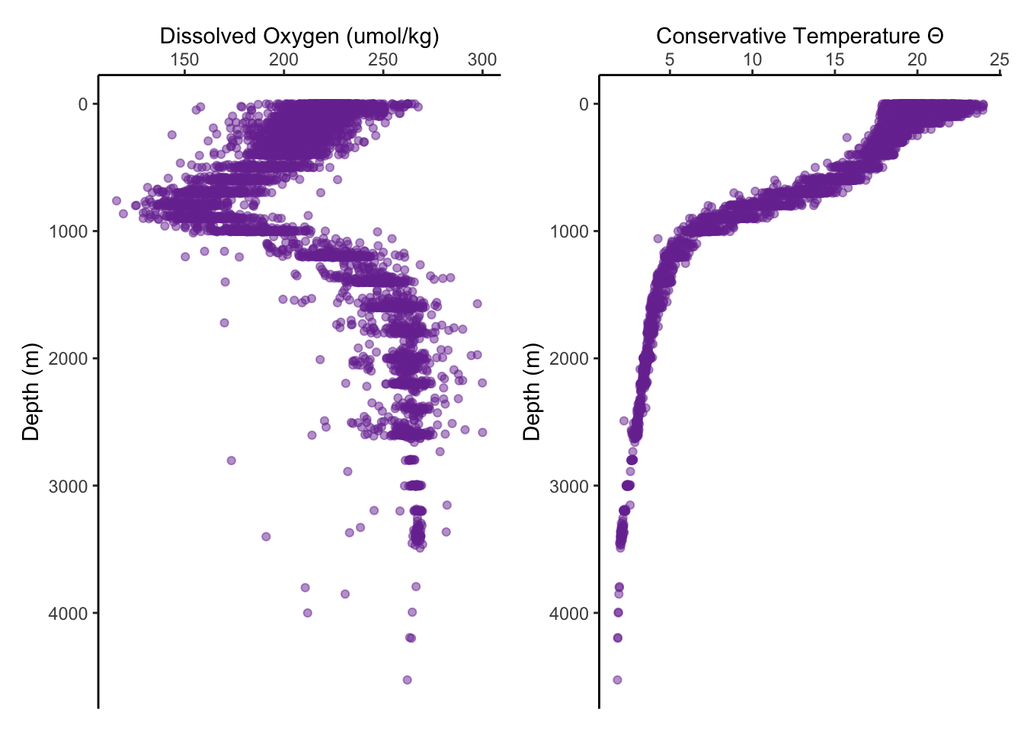

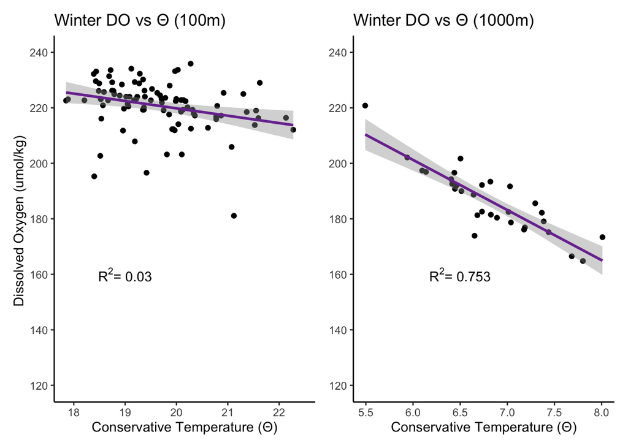

### Correlation for Summer

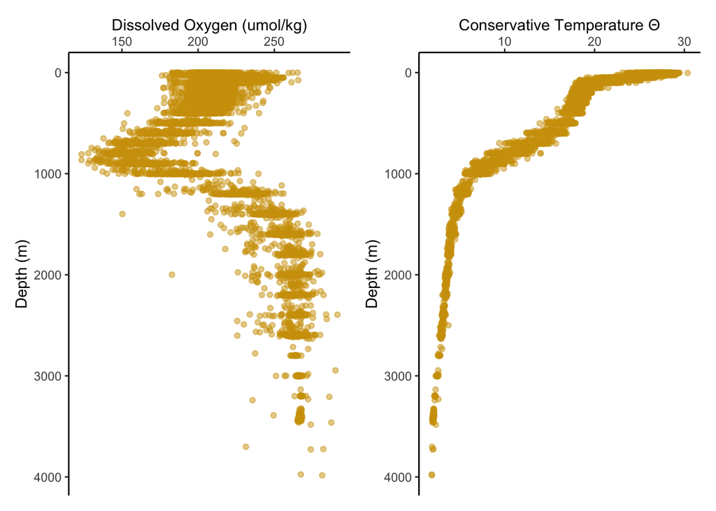

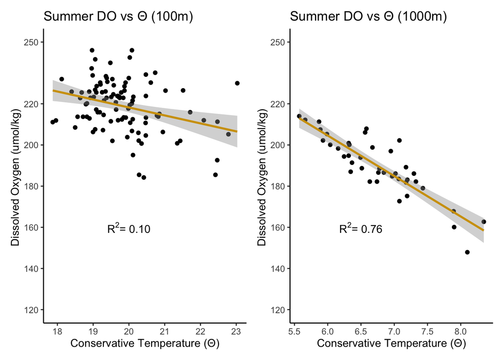

# Discussion

There seems none significance differences of Dissolved Oxygen and Conservative Temperature within depth seasonally. Also there appears to be none difference between winter and summer. However, there is a difference in correlation between depths in both seasons.

There is no correlation of Dissolved oxygen vs Conservative Temperature at 100m (R-squared - winter = 0.03, summer = 0.10), nevertheless, it exist a negative correlation at 1000m ( R-squared - winter = 0.75, summer = 0.76). At 1000m the higher the conservative temperature, the lower will be the Dissolved Oxygen concentration.

The lack of correlation between this two parameter at 100m may be due to the multiple factors that dictate the concentration of dissolved oxygen in the surface, such as: Temperature, salinity, and biological activity (Primary Production). At 1000m, factor as salinity and Biological activity may not have much effect, increasing the correlation of Dissolved oxygen vs temperature at higher depths.